# DA0402_NumPy slides

## **유니버설 함수**:

- 유니버설 함수 (ufunc): ndarray 안에 있는 데이터 원소별로 연산을 수행하는 함수.
- 하나 이상의 스칼라 값을 받아서 하나 이상의 스칼라 결과 값을 반환하는 간단한 함수를 고속으로 수행할 수 있는 벡터화된 래퍼 함수.
- **단항 유니버설 함수**

```python
arr = np.arange(10)
arr
```

```
array([0, 1, 2, 3, 4, 5, 6, 7, 8, 9])
```

```python
np.sqrt(arr)
```

```
array([ 0.    ,  1.    ,  1.4142,  1.7321,  2.    ,  2.2361,  2.4495,
        2.6458,  2.8284,  3.    ])
```

```python
np.exp(arr)
```

```
array([    1.    ,     2.7183,     7.3891,    20.0855,    54.5982,
         148.4132,   403.4288,  1096.6332,  2980.958 ,  8103.0839])
```

- **이항 유니버설 함수와 여러 배열을 반환하는 유니버설 함수 (136쪽, 137쪽 표 참고)**

```python
x = randn(8)
y = randn(8)
x
```

```
array([-0.0119,  1.0048,  1.3272, -0.9193, -1.5491,  0.0222,  0.7584,
       -0.6605])
```

```python
y
```

```
array([ 0.8626, -0.01  ,  0.05  ,  0.6702,  0.853 , -0.9559, -0.0235,
       -2.3042])
```

```python
np.maximum(x, y) # element-wise maximum
```

```
array([ 0.8626,  1.0048,  1.3272,  0.6702,  0.853 ,  0.0222,  0.7584,
       -0.6605])
```

```python
arr = randn(7) * 5
arr
```

```
array([-3.2623, -6.0915, -6.663 ,  5.3731,  3.6182,  3.45  ,  5.0077])
```

```python
np.modf(arr)
```

```
(array([-0.2623, -0.0915, -0.663 ,  0.3731,  0.6182,  0.45  ,  0.0077]),
 array([-3., -6., -6.,  5.,  3.,  3.,  5.]))
```

## **배열을 사용한 데이터 처리**

```python
points = np.arange(-5, 5, 0.01) # 1000 equally spaced points
```

```python
xs, ys = np.meshgrid(np.sin(points), np.cos(points))
ys
```

```
array([[ 0.2837,  0.2837,  0.2837, ...,  0.2837,  0.2837,  0.2837],
       [ 0.2741,  0.2741,  0.2741, ...,  0.2741,  0.2741,  0.2741],
       [ 0.2644,  0.2644,  0.2644, ...,  0.2644,  0.2644,  0.2644],
       ...,
       [ 0.2548,  0.2548,  0.2548, ...,  0.2548,  0.2548,  0.2548],
       [ 0.2644,  0.2644,  0.2644, ...,  0.2644,  0.2644,  0.2644],
       [ 0.2741,  0.2741,  0.2741, ...,  0.2741,  0.2741,  0.2741]])
```

```python
from matplotlib.pyplot import imshow, title
%matplotlib inline
```

```python
import matplotlib.pyplot as plt
z = np.sqrt(xs ** 2 + ys ** 2)
z.shape
```

```
(1000, 1000)
```

```
Text(0.5,1,u'Image plot of $\\sqrt{x^2 + y^2}$ for a grid of values')
```

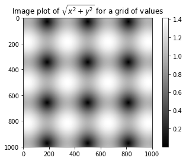

```python
plt.imshow(z, cmap=plt.cm.gray); plt.colorbar()
plt.title("Image plot of $\sqrt{x^2 + y^2}$ for a grid of values")
```

### **배열연산으로 조건절 표현하기**

```python
xarr = np.array([1.1, 1.2, 1.3, 1.4, 1.5])
yarr = np.array([2.1, 2.2, 2.3, 2.4, 2.5])
cond = np.array([True, False, True, True, False])
```

```python
result = [(x if c else y)
          for x, y, c in zip(xarr, yarr, cond)]
result
```

```
[1.1000000000000001, 2.2000000000000002, 1.3, 1.3999999999999999, 2.5]
```

```python
result = np.where(cond, xarr, yarr)
result
```

```
array([ 1.1,  2.2,  1.3,  1.4,  2.5])
```

```python
arr = randn(4, 4)
arr
```

```
array([[-0.5031, -0.6223, -0.9212, -0.7262],
       [ 0.2229,  0.0513, -1.1577,  0.8167],
       [ 0.4336,  1.0107,  1.8249, -0.9975],
       [ 0.8506, -0.1316,  0.9124,  0.1882]])
```

```python
np.where(arr > 0, 2, -2)
```

```
array([[-2, -2, -2, -2],
       [ 2,  2, -2,  2],
       [ 2,  2,  2, -2],
       [ 2, -2,  2,  2]])
```

```python
np.where(arr > 0, 2, arr) # set only positive values to 2
```

```
array([[-0.5031, -0.6223, -0.9212, -0.7262],
       [ 2.    ,  2.    , -1.1577,  2.    ],
       [ 2.    ,  2.    ,  2.    , -0.9975],
       [ 2.    , -0.1316,  2.    ,  2.    ]])
```

```python
n = 10
result = []
for i in range(n):
    if cond1[i] and cond2[i]:
        result.append(0)
    elif cond1[i]:
        result.append(1)
    elif cond2[i]:
        result.append(2)
    else:
        result.append(3)
```

파이썬 기본구문으로는 위와 같이 표현하는데 numpy where 메소드를 이용해 아래와 같이 표현 가능

```python
np.where(cond1 & cond2, 0,
         np.where(cond1, 1,
                  np.where(cond2, 2, 3)))
```

### **수학 메소드와 통계 메소드 (142쪽 표 참고)**

```python
arr = np.random.randn(5, 4) # normally-distributed data
arr
```

```
array([[ 2.1695, -0.1149,  2.0037,  0.0296],
       [ 0.7953,  0.1181, -0.7485,  0.585 ],
       [ 0.1527, -1.5657, -0.5625, -0.0327],
       [-0.929 , -0.4826, -0.0363,  1.0954],
       [ 0.9809, -0.5895,  1.5817, -0.5287]])
```

```python
arr.mean()
```

```
0.19607051119998253
```

```python
np.mean(arr)
```

```
0.19607051119998253
```

```python
arr.sum()
```

```
3.9214102239996507
```

mean이나 sum 같은 함수는 axis 인자를 받아 해당 axis에 대한 통계를 계산하고 한 차수 낮은 배열을 반환한다.

```python
arr.mean(axis=1)
```

```
array([ 1.022 ,  0.1875, -0.502 , -0.0881,  0.3611])
```

```python
arr.sum(0)
```

```
array([ 3.1693, -2.6345,  2.2381,  1.1486])
```

```python
arr = np.array([[0, 1, 2], [3, 4, 5], [6, 7, 8]])
arr
```

```
array([[0, 1, 2],
       [3, 4, 5],
       [6, 7, 8]])
```

cumsum과 cumprod 메소드는 중간 계산 값을 담고 있는 배열을 반환한다.

```python
arr.cumsum(0)
```

```
array([[ 0,  1,  2],
       [ 3,  5,  7],
       [ 9, 12, 15]])
```

```python
arr.cumprod(1)
```

```
array([[  0,   0,   0],
       [  3,  12,  60],
       [  6,  42, 336]])
```

### **불리언 배열을 위한 메소드**

불리언 배열에 대한 sum 메소드를 실행하면 True인 원소의 개수를 반환한다.

```python
arr = randn(100)
(arr > 0).sum() # Number of positive values
```

```
48
```

```python
bools = np.array([False, False, True, False])
bools
```

```
array([False, False,  True, False], dtype=bool)
```

any 메소드는 하나 이상의 True가 있는지 검사하고, all 메소드는 모든 원소가 True인지 검사한다. 0이 아닌 원소는 모두 True로 간주한다.

```python
bools.any()
```

```
True
```

```python
bools.all()
```

```
False
```

### **정렬**

NumPy 배열도 sort 메소드를 이용해 정렬할 수 있다. np.sort() 메소드는 배열을 직접 변경하지 않고 정렬된 결과의 사본을 반환한다.

```python
arr = randn(8)
arr
```

```
array([-1.6667,  0.6715, -2.4175,  0.6362,  0.5451, -1.7018,  0.1817,
       -1.187 ])
```

```python
arr.sort()
arr
```

```
array([-2.4175, -1.7018, -1.6667, -1.187 ,  0.1817,  0.5451,  0.6362,
        0.6715])
```

다차원 배열의 정렬은 sort 메소드에 넘긴 축의 값에 따라 정렬한다.

```python
arr = randn(5, 3)
arr
```

```
array([[ 0.5307, -0.5814,  0.3326],
       [-0.312 , -0.7644,  1.683 ],
       [-0.1881, -0.2725, -1.4397],
       [-0.2607, -1.0419, -0.7625],
       [ 2.1071, -0.9366,  0.7189]])
```

```python
arr.sort(1)
```

```python
arr
```

```
array([[-0.5814,  0.3326,  0.5307],
       [-0.7644, -0.312 ,  1.683 ],
       [-1.4397, -0.2725, -0.1881],
       [-1.0419, -0.7625, -0.2607],
       [-0.9366,  0.7189,  2.1071]])
```

아래와 같이 배열을 정렬한 후 특정 분위의 값을 선택하면 배열의 분위수를 쉽게 구할 수 있다.

```python
large_arr = randn(1000)
large_arr.sort()
large_arr[int(0.05 * len(large_arr))] # 5% quantile
```

```
-1.5311513550102103
```

### **집합 함수**

- **np.unique**

```python
names = np.array(['Bob', 'Joe', 'Will', 'Bob', 'Will', 'Joe', 'Joe'])
np.unique(names)
```

```
array(['Bob', 'Joe', 'Will'],
      dtype='|S4')
```

```python
ints = np.array([3, 3, 3, 2, 2, 1, 1, 4, 4])
np.unique(ints)
```

```
array([1, 2, 3, 4])
```

- **np.unique와 같은 기능을 하는 파이썬 코드**

```python
sorted(set(names))
```

```
['Bob', 'Joe', 'Will']
```

- **np.in1d**

```python
values = np.array([6, 0, 0, 3, 2, 5, 6])
np.in1d(values, [2, 3, 6])
```

```
array([ True, False, False,  True,  True, False,  True], dtype=bool)
```

```python
arr1 = np.arange(16).reshape(2, 8)
arr2 = np.arange(16).reshape(2, 8)
```

```python
arr2[0][:] = 4
```

```python
np.where(arr1 != arr2)
```

```
(array([0, 0, 0, 0, 0, 0, 0]), array([0, 1, 2, 3, 5, 6, 7]))
```

```python
np.all(arr1 == arr2)
```

```
False
```

- **NumPy 집합 함수**

| 메소드 | 설명 |
| --- | --- |
| unique (x) | 배열 x에서 중복된 원소를 제거한 후 정렬하여 반환한다. |
| intersect1d (x, y) | 배열 x와 y에 공통적으로 존재하는 원소를 정렬하여 반환한다. |
| union1d (x, y) | 두 배열의 합집합을 반환한다. |
| in1d (x, y) | x의 원소 중 y의 원소를 포함하는지를 나타내는 불리언 배열을 반환한다. |
| setdiff1d (x, y) | x와 y의 차집합을 반환한다. |
| setxor1d (x, y) | 한 배열에는 포함되지만 두 배열 모두에는 포함되지 않는 원소들의 집합인 대칭차집합을 반환한다. |

## **배열의 파일 입출력**

### **배열을 바이너리 형식으로 디스크에 저장하기**

```python
arr = np.arange(10)
np.save('some_array', arr)
```

```python
!dir some_array*
```

```
 C 드라이브의 볼륨: System
 볼륨 일련 번호: 5CC0-0876

 c:\Users\shbaek\Documents\DAPython02 디렉터리

2017-11-20  오전 03:00               120 some_array.npy
               1개 파일                 120 바이트
               0개 디렉터리  95,259,992,064 바이트 남음
```

```python
np.load('some_array.npy')
```

```
array([0, 1, 2, 3, 4, 5, 6, 7, 8, 9])
```

np.savez 함수를 이용하면 여러 배열을 압축된 형식으로 저장할 수 있다. 저장하려는 배열은 키워드 인자 형태로 전달한다.

```python
np.savez('array_archive.npz', a=arr, b=arr)
```

```python
!dir array_archive.npz
```

```
 C 드라이브의 볼륨: System
 볼륨 일련 번호: 5CC0-0876

 c:\Users\shbaek\Documents\DAPython02 디렉터리

2017-11-20  오전 03:00               434 array_archive.npz
               1개 파일                 434 바이트
               0개 디렉터리  95,259,992,064 바이트 남음
```

```python
arch = np.load('array_archive.npz')
arch
```

```
<numpy.lib.npyio.NpzFile at 0x7aea470>
```

```python
arch['b']
```

```
array([0, 1, 2, 3, 4, 5, 6, 7, 8, 9])
```

```python
arch.close()
```

```python
!del some_array.npy
```

```python
!del array_archive.npz
```

### **텍스트 파일 불러오기와 저장하기**

```python
!type ch04\\array_ex.txt
```

```
0.580052,0.186730,1.040717,1.134411
0.194163,-0.636917,-0.938659,0.124094
-0.126410,0.268607,-0.695724,0.047428
-1.484413,0.004176,-0.744203,0.005487
2.302869,0.200131,1.670238,-1.881090
-0.193230,1.047233,0.482803,0.960334
```

```python
arr = np.loadtxt('ch04/array_ex.txt', delimiter=',')
arr
```

```
array([[ 0.5801,  0.1867,  1.0407,  1.1344],
       [ 0.1942, -0.6369, -0.9387,  0.1241],
       [-0.1264,  0.2686, -0.6957,  0.0474],
       [-1.4844,  0.0042, -0.7442,  0.0055],
       [ 2.3029,  0.2001,  1.6702, -1.8811],
       [-0.1932,  1.0472,  0.4828,  0.9603]])
```

## **선형 대수**

numpy 배열을 이용한 행렬의 곱 (np.dot())

```python
x = np.array([[1., 2., 3.], [4., 5., 6.]])
y = np.array([[6., 23.], [-1, 7], [8, 9]])
```

```python
display(x)
display(y)
x.dot(y)  # equivalently np.dot(x, y)
```

```
array([[ 1.,  2.,  3.],
       [ 4.,  5.,  6.]])
```

```
array([[  6.,  23.],
       [ -1.,   7.],
       [  8.,   9.]])
```

```
array([[  28.,   64.],
       [  67.,  181.]])
```

2차원 배열과 곱셈이 가능한 크기의 1차원 배열 간 행렬 곱의 결과는 1차원 배열이 된다.

```python
np.dot(x, np.ones(3))
```

```
array([  6.,  15.])
```

numpy.linalg는 행렬의 분할과 역행렬, 행렬식 등을 포함한다.

```python
np.random.seed(12345)
```

```python
from numpy.linalg import inv, qr
X = randn(5, 5)
X
```

```
array([[-0.2047,  0.4789, -0.5194, -0.5557,  1.9658],
       [ 1.3934,  0.0929,  0.2817,  0.769 ,  1.2464],
       [ 1.0072, -1.2962,  0.275 ,  0.2289,  1.3529],
       [ 0.8864, -2.0016, -0.3718,  1.669 , -0.4386],
       [-0.5397,  0.477 ,  3.2489, -1.0212, -0.5771]])
```

```python
X.T
```

```
array([[-0.2047,  1.3934,  1.0072,  0.8864, -0.5397],
       [ 0.4789,  0.0929, -1.2962, -2.0016,  0.477 ],
       [-0.5194,  0.2817,  0.275 , -0.3718,  3.2489],
       [-0.5557,  0.769 ,  0.2289,  1.669 , -1.0212],
       [ 1.9658,  1.2464,  1.3529, -0.4386, -0.5771]])
```

```python
mat = X.T.dot(X)
mat
```

```
array([[  4.075 ,  -3.3059,  -1.3073,   3.4466,   2.6197],
       [ -3.3059,   6.1523,   1.7149,  -4.3193,  -0.0938],
       [ -1.3073,   1.7149,  11.1187,  -3.3702,  -2.0097],
       [  3.4466,  -4.3193,  -3.3702,   4.7812,   0.0331],
       [  2.6197,  -0.0938,  -2.0097,   0.0331,   7.7736]])
```

```python
inv(mat)
```

```
array([[ 3.0361, -0.1808, -0.6878, -2.8285, -1.1911],
       [-0.1808,  0.5035,  0.1215,  0.6702,  0.0956],
       [-0.6878,  0.1215,  0.2904,  0.8081,  0.3049],
       [-2.8285,  0.6702,  0.8081,  3.4152,  1.1557],
       [-1.1911,  0.0956,  0.3049,  1.1557,  0.6051]])
```

```python
mat.dot(inv(mat))
```

```
array([[ 1., -0.,  0.,  0., -0.],
       [ 0.,  1.,  0.,  0.,  0.],
       [ 0., -0.,  1.,  0., -0.],
       [-0., -0.,  0.,  1.,  0.],
       [ 0.,  0.,  0.,  0.,  1.]])
```

```python
q, r = qr(mat)
q
```

```
array([[-0.5883, -0.2619, -0.2013, -0.3233, -0.6635],
       [ 0.4772, -0.6609,  0.1734, -0.5501,  0.0532],
       [ 0.1887, -0.0806, -0.9635, -0.0266,  0.1698],
       [-0.4975,  0.1618,  0.0179, -0.5581,  0.6438],
       [-0.3782, -0.6797,  0.0276,  0.5298,  0.3371]])
```

```python
r
```

```
array([[ -6.9271,   7.389 ,   6.1227,  -7.1163,  -4.9215],
       [  0.    ,  -3.9735,  -0.8671,   2.9747,  -5.7402],
       [  0.    ,   0.    , -10.2681,   1.8909,   1.6079],
       [  0.    ,   0.    ,   0.    ,  -1.2996,   3.3577],
       [  0.    ,   0.    ,   0.    ,   0.    ,   0.5571]])
```

- **자주 사용하는 NumPy 선형대수 함수**

| 함수 | 설명 |
| --- | --- |
| numpy.diag | 정사각 행렬의 대각/비대각 원소를 1차원 배열로 반환하거나 1차원 배열을 대각선 원소로 하고, 나머지는 0으로 채운 단위 행렬을 반환한다. |
| numpy.dot | 행렬 곱셈 |
| numpy.trace | 행렬의 대각선 원소의 합을 계산한다. |
| numpy.linalg.det | 행렬식을 계산한다. |
| numpy.linalg.eig | 정사각 행렬의 고유 값과 고유벡터를 계산한다. |
| numpy.linalg.inv | 정사각 행렬의 역행렬을 계산한다. |
| numpy.linalg.pinv | 행렬의 무어-펜로즈 유사역원 역행렬을 구한다. |
| numpy.linalg.qr | QR 분해를 계산한다. |
| numpy.linalg.svd | 특이값 분해 (SVD)를 계산한다. |
| numpy.linalg.solve | A가 정사각 행렬일 때, Ax = b를 만족하는 x를 구한다. |
| numpy.linalg.lstsq | y = xb를 만족하는 최소제곱해를 구한다. |

## **난수 생성**

numpy.random 모듈은 파이썬 내장 random 함수를 보강하여 다양한 종류의 확률분포로부터 효과적으로 표본 값을 생성하는 데 사용된다. 예를 들어 normal을 사용하여 표준정규분포로부터 4x4 크기의 표본을 생성할 수 있다.

```python
samples = np.random.normal(size=(4, 4))
samples
```

```
array([[ 0.1241,  0.3026,  0.5238,  0.0009],
       [ 1.3438, -0.7135, -0.8312, -2.3702],
       [-1.8608, -0.8608,  0.5601, -1.2659],
       [ 0.1198, -1.0635,  0.3329, -2.3594]])
```

파이썬 내장 random 모듈을 사용하는 경우와 numpy random 모듈을 사용하는 경우의 성능을 비교해보자.

```python
from random import normalvariate
N = 1000000
%timeit samples = [normalvariate(0, 1) for _ in range(N)]
%timeit np.random.normal(size=N)
```

```
1 loop, best of 3: 4.61 s per loop
10 loops, best of 3: 162 ms per loop
```

- **일부 numpy.random 함수**

| 함수 | 설명 |
| --- | --- |
| seed | 난수 발생기의 시드 (seed)를 지정한다. |
| permutation | 순서를 임의로 바꾸거나 임의의 순열을 반환한다. |
| shuffle | 리스트나 배열의 순서를 뒤섞는다. |
| rand | 균등분포에서 표본을 추출한다. |
| randint | 주어진 최소/최대 범위 안에서 임의의 난수를 추출한다. |
| randn | 표준편차가 1이고 평균 값이 0인 정규분포(MATLAB과 같은 방식)에서 표본을 추출한다. |
| binomial | 이항분포에서 표본을 추출한다. |
| normal | 정규분포(가우시안)에서 표본을 추출한다. |
| beta | 베타분포에서 표본을 추출한다. |
| chisquare | 카이제곱분포에서 표본을 추출한다. |
| gamma | 감마분포에서 표본을 추출한다. |
| uniform | 균등(0, 1)분포에서 표본을 추출한다. |

## **계단 오르내리기 예제**

- **파이썬 내장 random 모듈을 사용, 계산 오르내리기 1000번 수행하는 코드**

```python
import random
position = 0
walk = [position]
steps = 1000
for i in range(steps):
    step = 1 if random.randint(0, 1) else -1
    position += step
    walk.append(position)
walk[:20]
```

```
[0, -1, 0, 1, 0, -1, -2, -3, -4, -5, -6, -5, -6, -5, -6, -5, -4, -3, -4, -3]
```

[figure not shown]

```python
import matplotlib.pyplot as plt

plt.plot(walk[0:100])
plt.ylabel('steps')
plt.show()
```

```python
np.random.seed(12345)
```

```python
nsteps = 1000
draws = np.random.randint(0, 2, size=nsteps)
steps = np.where(draws > 0, 1, -1)
walk = steps.cumsum()
```

```python
walk.min()
```

```
-3
```

```python
walk.max()
```

```
31
```

```python
(np.abs(walk) >= 10).argmax()
```

```
37
```

### **한 번에 계단 오르내리기 시뮬레이션하기**

```python
nwalks = 5000
nsteps = 1000
draws = np.random.randint(0, 2, size=(nwalks, nsteps)) # 0 or 1
steps = np.where(draws > 0, 1, -1)
walks = steps.cumsum(1)
walks
```

```
array([[  1,   0,   1, ...,   8,   7,   8],
       [  1,   0,  -1, ...,  34,  33,  32],
       [  1,   0,  -1, ...,   4,   5,   4],
       ...,
       [  1,   2,   1, ...,  24,  25,  26],
       [  1,   2,   3, ...,  14,  13,  14],
       [ -1,  -2,  -3, ..., -24, -23, -22]])
```

```python
walks.max()
```

```
138
```

```python
walks.min()
```

```
-133
```

```python
hits30 = (np.abs(walks) >= 30).any(1)
hits30
```

```
array([False,  True, False, ..., False,  True, False], dtype=bool)
```

```python
hits30.sum() # Number that hit 30 or -30
```

```
3410
```

```python
crossing_times = (np.abs(walks[hits30]) >= 30).argmax(1)
crossing_times.mean()
```

```
498.88973607038122
```

```python
steps = np.random.normal(loc=0, scale=0.25,
                         size=(nwalks, nsteps))
```

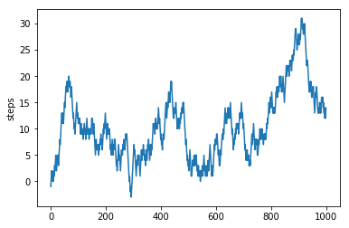

```python
plt.plot(walk[0:1000])
plt.ylabel('steps')
plt.show()
```